# Prudential - Response: Binomial - Method: glm

Francia Moscoso

April 29, 2016

**Logistic Regression - binomial approach.**

```r
library(dplyr)
library(corrplot)
library(ggplot2)
library(gridExtra)
library(MASS)
library(ROCR)
library(caTools)
```

**Function that populates missing values with the median**

```r
manage_na <- function(tempo)
{
  for(i in 1:ncol(tempo))
  {
    if(is.numeric(tempo[,i]))
    {
      tempo[is.na(tempo[,i]),i] <- median(tempo[!is.na(tempo[,i]),i])
    }
  }
  tempo
}
```

**Loading Data Sets**

```r
# Working Directory
setwd("~/SprintboardProject/PrudentialIns/Binomial_glm")

train <- read.csv("../DataSets/train.csv", header = TRUE)
test <-  read.csv("../DataSets/test.csv", header = TRUE)
```

**create a new column “Approved” to indicate that the application has a max value of 8 or not. Approved = 1 only when Response = 8. This new variable “Approved” will allow to use ‘glm’ method where the dependent variable needs to be binary.**

```r
train$Approved  <- 0
train$Approved[train$Response==8]  <- 1   # Approved = 1 when train$Response = 8

# Approved values
table(train$Approved)
```

```
    0     1
39892 19489
```

**Splitting data with ratio 75/25.**

```r
set.seed(3000)
# 75% of data in Training set
split <- sample.split(train$Response, SplitRatio = 0.75)

#Splitting data
trainLog <- subset(train, split==TRUE)
testLog  <- subset(train, split==FALSE)
```

**Analyze dependent variable trainLog Approved**

```r
nrow(trainLog)
```

```
[1] 44536
```

```r
table(trainLog$Response)
```

```
    1     2     3     4     5     6     7     8
 4655  4914   760  1071  4074  8425  6020 14617
```

```r
table(trainLog$Approved)
```

```
    0     1
29919 14617
```

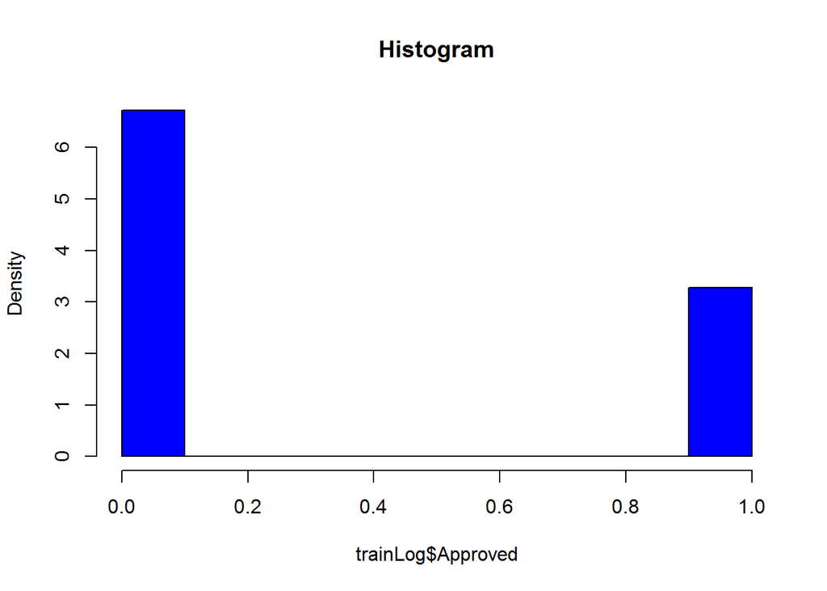

```r
hist(trainLog$Approved, main="Histogram", prob=T, breaks = 8,col="blue")
```

**Populate trainLog missing values with the median**

```r
trainLog <- manage_na(trainLog[,-c(1)])     #   Except columns 1 (ID)

testLog <- manage_na(testLog[,-c(1)])
```

**Alphabetic Categorical variable in the trainLog data set: Product_Info_2.** **Getting the frequency**

```r
ProductInfo2 <- data.frame(table(trainLog$Product_Info_2))
ProductInfo2_Sorted <- ProductInfo2 %>% arrange(desc(Freq))
head(ProductInfo2_Sorted)
```

```
  Var1  Freq
1   D3 10778
2   D4  8155
3   A8  5113
4   D1  4895
5   D2  4731
6   E1  1974
```

**Summarize the categorical variable Product_Info_2 by Approved value (0,1)**

```r
trainLog$Approved <- as.factor(trainLog$Approved)
ProductInfo2 <- trainLog %>%
                 group_by(Approved,Product_Info_2) %>% summarise(Tot_Count= n())
```

**Plot the count of Product_Info_2 by Approved value.**

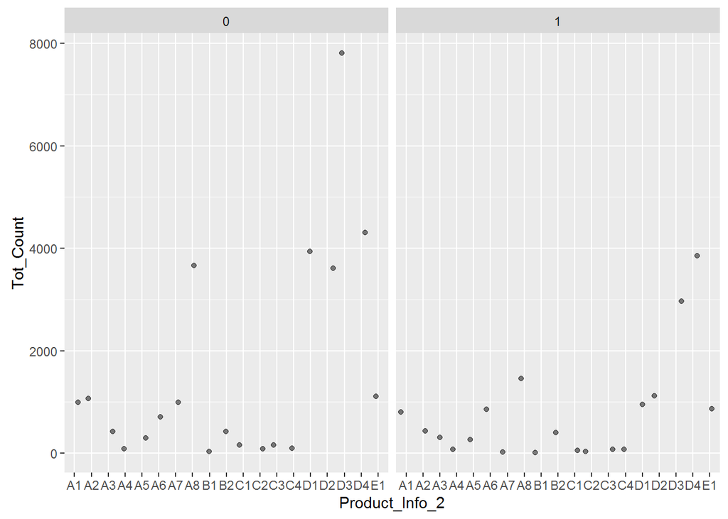

```r
ggplot(ProductInfo2, aes(x=Product_Info_2, y =Tot_Count)) +
       facet_wrap(~Approved) + geom_jitter(alpha=1/2, position=position_jitter(h=0))
```

**Approved ratio**

```r
table(trainLog$Approved)
```

```
    0     1
29919 14617
```

```r
# Percentage of Approved observations (Response=8)
table(trainLog$Approved)[2]/nrow(trainLog)
```

```
        1
0.3282064
```

**We need a baseline method to compare our predictions. In this case, we can say that 14,617 out of 44,536 obs were Approved (Response=8)in our training data set. Therefore, our base line method has an accuracy of 32.8% and that is what we will try to beat with a logistic regression model.** **The AIC value was improved by removing variables that were not significant in the model:**

```r
trainFit = glm(Approved ~ Product_Info_1 + Product_Info_2 +
                          Product_Info_4 + Product_Info_5 +
                          InsuredInfo_2  + InsuredInfo_4  +
                          InsuredInfo_5  + InsuredInfo_6  + InsuredInfo_7 +
                          Insurance_History_1 + Insurance_History_2 +
                          Family_Hist_1 + Family_Hist_3 +
                          Family_Hist_4 + Family_Hist_5 +
                          Medical_History_3 +
                          Medical_History_4  + Medical_History_5 +
                          Medical_History_7  + Medical_History_10 +
                          Medical_History_13 + Medical_History_14 +
                          Medical_History_15 +
                          Medical_History_17 + Medical_History_18 +
                          Medical_History_20 + Medical_History_23 +
                          Medical_History_24 + Medical_History_30 +
                          Medical_History_31 + Medical_History_32 +
                          Medical_History_39 + Medical_History_40 +
                          Medical_Keyword_3  + Medical_Keyword_12  +
                          Medical_Keyword_15 + Medical_Keyword_22  +
                          Ht + Wt +  Ins_Age,
                          data = trainLog, family=binomial)

summary(trainFit)
```

```
Call:
glm(formula = Approved ~ Product_Info_1 + Product_Info_2 + Product_Info_4 +
    Product_Info_5 + InsuredInfo_2 + InsuredInfo_4 + InsuredInfo_5 +
    InsuredInfo_6 + InsuredInfo_7 + Insurance_History_1 + Insurance_History_2 +
    Family_Hist_1 + Family_Hist_3 + Family_Hist_4 + Family_Hist_5 +
    Medical_History_3 + Medical_History_4 + Medical_History_5 +
    Medical_History_7 + Medical_History_10 + Medical_History_13 +
    Medical_History_14 + Medical_History_15 + Medical_History_17 +
    Medical_History_18 + Medical_History_20 + Medical_History_23 +
    Medical_History_24 + Medical_History_30 + Medical_History_31 +
    Medical_History_32 + Medical_History_39 + Medical_History_40 +
    Medical_Keyword_3 + Medical_Keyword_12 + Medical_Keyword_15 +
    Medical_Keyword_22 + Ht + Wt + Ins_Age, family = binomial,
    data = trainLog)

Deviance Residuals:
    Min       1Q   Median       3Q      Max
-2.8971  -0.5655  -0.1359   0.6145   4.1564

Coefficients:
                      Estimate Std. Error z value Pr(>|z|)
(Intercept)         -9.052e+00  1.605e+00  -5.639 1.71e-08 ***
Product_Info_1      -8.113e-01  8.530e-02  -9.511  < 2e-16 ***
Product_Info_2A2    -3.068e-01  1.041e-01  -2.946 0.003217 **
Product_Info_2A3    -1.919e-03  1.163e-01  -0.017 0.986832
Product_Info_2A4     3.024e-01  2.206e-01   1.371 0.170280
Product_Info_2A5     1.964e-01  1.249e-01   1.573 0.115692
Product_Info_2A6     2.513e-01  9.059e-02   2.775 0.005528 **
Product_Info_2A7    -3.247e+00  2.298e-01 -14.132  < 2e-16 ***
Product_Info_2A8    -3.623e-01  7.952e-02  -4.556 5.21e-06 ***
Product_Info_2B1    -1.732e-01  5.114e-01  -0.339 0.734887
Product_Info_2B2     2.575e-01  1.106e-01   2.329 0.019884 *
Product_Info_2C1    -4.309e-01  2.101e-01  -2.051 0.040274 *
Product_Info_2C2    -2.594e-01  2.809e-01  -0.923 0.355763
Product_Info_2C3    -1.228e-01  2.013e-01  -0.610 0.541870
Product_Info_2C4     3.541e-01  2.180e-01   1.624 0.104276
Product_Info_2D1    -3.329e-01  8.276e-02  -4.022 5.76e-05 ***
Product_Info_2D2    -1.574e-01  8.171e-02  -1.926 0.054076 .
Product_Info_2D3    -2.003e-01  7.168e-02  -2.795 0.005193 **
Product_Info_2D4     1.928e-01  7.059e-02   2.731 0.006315 **
```

[output cut: 34 more lines]

```
Medical_Keyword_15  -2.145e+00  1.054e-01 -20.358  < 2e-16 ***
Medical_Keyword_22   3.044e-01  8.410e-02   3.619 0.000295 ***
Ht                   1.191e+01  3.230e-01  36.885  < 2e-16 ***
Wt                  -2.037e+01  3.022e-01 -67.391  < 2e-16 ***
Ins_Age             -1.059e+00  1.160e-01  -9.125  < 2e-16 ***
---
Signif. codes:  0 '***' 0.001 '**' 0.01 '*' 0.05 '.' 0.1 ' ' 1

(Dispersion parameter for binomial family taken to be 1)

    Null deviance: 56374  on 44535  degrees of freedom
Residual deviance: 33324  on 44478  degrees of freedom
AIC: 33440

Number of Fisher Scoring iterations: 7
```

Tne model created dummy variables for the categorical variable Product_Info_2.  
**Compute the average prediction for each outcome**

```r
predictTrain = predict(trainFit, type="response")

# This will compute the average prediction for each outcome:
tapply(predictTrain, trainLog$Approved,mean)
```

```
        0         1
0.1806291 0.6302768
```

```r
summary(predictTrain)
```

```
   Min. 1st Qu.  Median    Mean 3rd Qu.    Max.
0.00000 0.02622 0.22510 0.32820 0.61400 0.99080
```

```r
write.csv(predictTrain, "predPrudentialResp.csv", row.names = T)
write.csv(trainLog$Approved, "predPrudentialAppr.csv", row.names = T)
```

**Predictions with diffent Thresholds**  
**Threshold = 0.5**

```r
ConfusionMatrix <- table(trainLog$Approved,predictTrain > 0.5)
ConfusionMatrix
```

```
    FALSE  TRUE
  0 26056  3863
  1  3972 10645
```

```r
#Sensitivity
True_Positive_Rate = ConfusionMatrix[2,2] / (ConfusionMatrix[2,1] + ConfusionMatrix[2,2])
True_Positive_Rate
```

```
[1] 0.7282616
```

```r
False_Positive_Error_Rate = ConfusionMatrix[1,2] / (ConfusionMatrix[1,1] + ConfusionMatrix[1,2])
False_Positive_Error_Rate
```

```
[1] 0.1291153
```

```r
Specificity  <- ConfusionMatrix[1,1] / (ConfusionMatrix[1,1] + ConfusionMatrix[1,2])
Specificity
```

```
[1] 0.8708847
```

**Threshold = 0.7**

```r
ConfusionMatrix <- table(trainLog$Approved,predictTrain > 0.7)
ConfusionMatrix
```

```
    FALSE  TRUE
  0 28316  1603
  1  7751  6866
```

```r
#Sensitivity
True_Positive_Rate = ConfusionMatrix[2,2] / (ConfusionMatrix[2,1] + ConfusionMatrix[2,2])
True_Positive_Rate
```

```
[1] 0.469727
```

```r
False_Positive_Error_Rate = ConfusionMatrix[1,2] / (ConfusionMatrix[1,1] + ConfusionMatrix[1,2])
False_Positive_Error_Rate
```

```
[1] 0.05357799
```

```r
Specificity  <- ConfusionMatrix[1,1] / (ConfusionMatrix[1,1] + ConfusionMatrix[1,2])
Specificity
```

```
[1] 0.946422
```

**Threshold = 0.2**

```r
ConfusionMatrix <- table(trainLog$Approved,predictTrain > 0.2)
ConfusionMatrix
```

```
    FALSE  TRUE
  0 20504  9415
  1   940 13677
```

```r
#Sensitivity
True_Positive_Rate = ConfusionMatrix[2,2] / (ConfusionMatrix[2,1] + ConfusionMatrix[2,2])
True_Positive_Rate
```

```
[1] 0.9356913
```

```r
False_Positive_Error_Rate = ConfusionMatrix[1,2] / (ConfusionMatrix[1,1] + ConfusionMatrix[1,2])
False_Positive_Error_Rate
```

```
[1] 0.314683
```

```r
Specificity  <- ConfusionMatrix[1,1] / (ConfusionMatrix[1,1] + ConfusionMatrix[1,2])
Specificity
```

```
[1] 0.685317
```

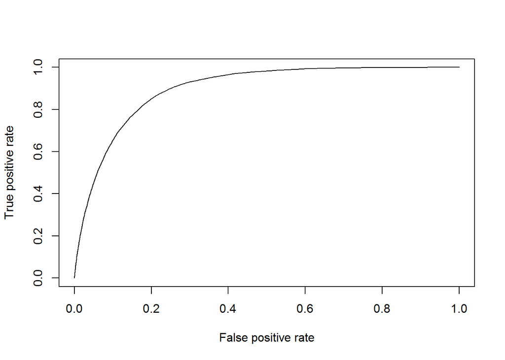

```r
ROCRpred = prediction(predictTrain,trainLog$Approved)

ROCRperf = performance(ROCRpred, "tpr", "fpr")

plot(ROCRperf)

plot(ROCRperf, colorsize=TRUE)
```

**Making predictions on testLog data set**

```r
dim(testLog)
```

```
[1] 14845   128
```

```r
predictTest = predict(trainFit, type="response", newdata = testLog)

summary(predictTest)
```

```
   Min. 1st Qu.  Median    Mean 3rd Qu.    Max.
0.00000 0.01491 0.14960 0.26740 0.48920 0.97410
```

**Calculate accuracy of the model**

```r
ConfusionMatrix <- table(testLog$Approved,predictTest > 0.2)
ConfusionMatrix
```

```
    FALSE TRUE
  0  7563 2410
  1   554 4318
```

```r
Accuracy <- (ConfusionMatrix[1,1] + ConfusionMatrix[2,2]) / nrow(testLog)
Accuracy
```

```
[1] 0.8003368
```

```r
False_Positive_Error_Rate = ConfusionMatrix[1,2] / (ConfusionMatrix[1,1] + ConfusionMatrix[1,2])
False_Positive_Error_Rate
```

```
[1] 0.2416525
```

```r
#Sensitivity
True_Positive_Rate = ConfusionMatrix[2,2] / (ConfusionMatrix[2,1] + ConfusionMatrix[2,2])
True_Positive_Rate
```

```
[1] 0.886289
```